# Yield Curve Inversion

Lucy Qu

2020-10-20

Every so often, we hear warnings from commentators on the “inverted yield curve” and its predictive power with respect to recessions and many of them think that, [*Yield curve inversion is viewed as a harbinger of recession*](https://www.bloomberg.com/news/articles/2019-08-14/u-k-yield-curve-inverts-for-first-time-since-financial-crisis). In our case we will look at US data and use the [FRED database](https://fred.stlouisfed.org/) to download historical yield curve rates, and plot the yield curves since 1999 to see *when and whether the yield curves have flattened.*

| symbol | var | maturity |
| --- | --- | --- |
| TB3MS | 3-Month Treasury Bill | 3m |
| TB6MS | 6-Month Treasury Bill | 6m |
| GS1 | 1-Year Treasury Rate | 1y |
| GS2 | 2-Year Treasury Rate | 2y |
| GS3 | 3-Year Treasury Rate | 3y |
| GS5 | 5-Year Treasury Rate | 5y |
| GS7 | 7-Year Treasury Rate | 7y |
| GS10 | 10-Year Treasury Rate | 10y |
| GS20 | 20-Year Treasury Rate | 20y |
| GS30 | 30-Year Treasury Rate | 30y |

```
## Rows: 6,774
## Columns: 3
## $ symbol <chr> "TB3MS", "TB3MS", "TB3MS", "TB3MS", "TB3MS", "TB3MS", "TB3MS",…
## $ date   <date> 1960-01-01, 1960-02-01, 1960-03-01, 1960-04-01, 1960-05-01, 1…
## $ price  <dbl> 4.35, 3.96, 3.31, 3.23, 3.29, 2.46, 2.30, 2.30, 2.48, 2.30, 2.…
```

# 1 Horizontal Trend

As most of us acknowledge, the yield level could be a good demonstrator of the prevailing economics and finanical markets. Whereas a suddenly dropping yield may indicate a widespread panic leading investors flocking into the T-bills and bonds market, a rising yield may indicate a recent OMO transaction or a USD appreciation. Here, we are trying to look at the yields on US rates by duration over time so that we may able to link the major market events with the movement of the rates along time.

## 1.1 Yields on US rates by duration since 1960

First, we looked at the the yields on US rates by duration since 1960:

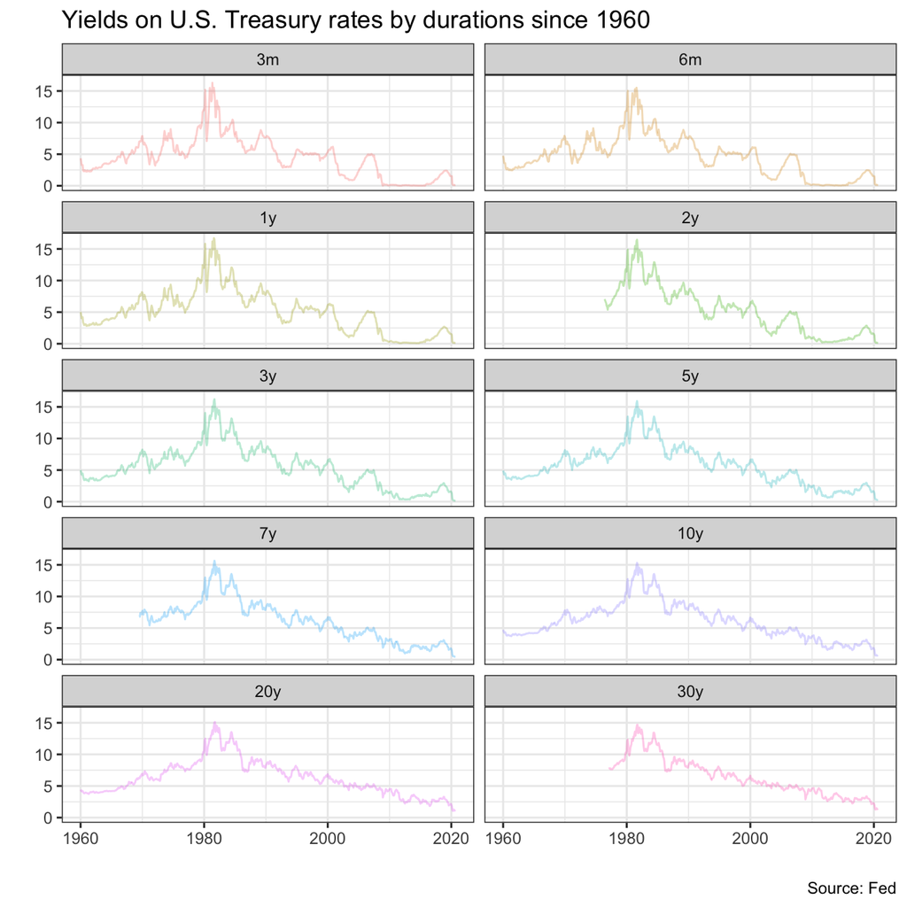

```r
yield_curve %>%
  ggplot(aes(x = date, y = price, color = maturity)) +
  geom_line(alpha = 0.3) +
  facet_wrap(~ maturity, ncol = 2) +
  theme_bw() +
  labs(title = "Yields on U.S. Treasury rates by durations since 1960", caption = "Source: Fed", x = "", y = "") +
  theme(legend.position = "none")
```

We found that: Yields with different maturities (the short term, mid term, and long terms rates) are generally following the similar time patterns and show positive correlation with each other; The volatility of short term rates are higher than that of the longer term rates.

# 2 Vertical Trend

Then, we compared the yields with different durations on the same axis to view the vertical structure of the yields:

## 2.1 Monthly yields on US rates by duration since 1999 on a year-by-year basis

```r
glimpse(yield_curve)
```

```
## Rows: 6,774
## Columns: 5
## $ symbol   <chr> "TB3MS", "TB3MS", "TB3MS", "TB3MS", "TB3MS", "TB3MS", "TB3MS…
## $ date     <date> 1960-01-01, 1960-02-01, 1960-03-01, 1960-04-01, 1960-05-01,…
## $ price    <dbl> 4.35, 3.96, 3.31, 3.23, 3.29, 2.46, 2.30, 2.30, 2.48, 2.30, …
## $ var      <chr> "3-Month Treasury Bill", "3-Month Treasury Bill", "3-Month T…
## $ maturity <fct> 3m, 3m, 3m, 3m, 3m, 3m, 3m, 3m, 3m, 3m, 3m, 3m, 3m, 3m, 3m, …
```

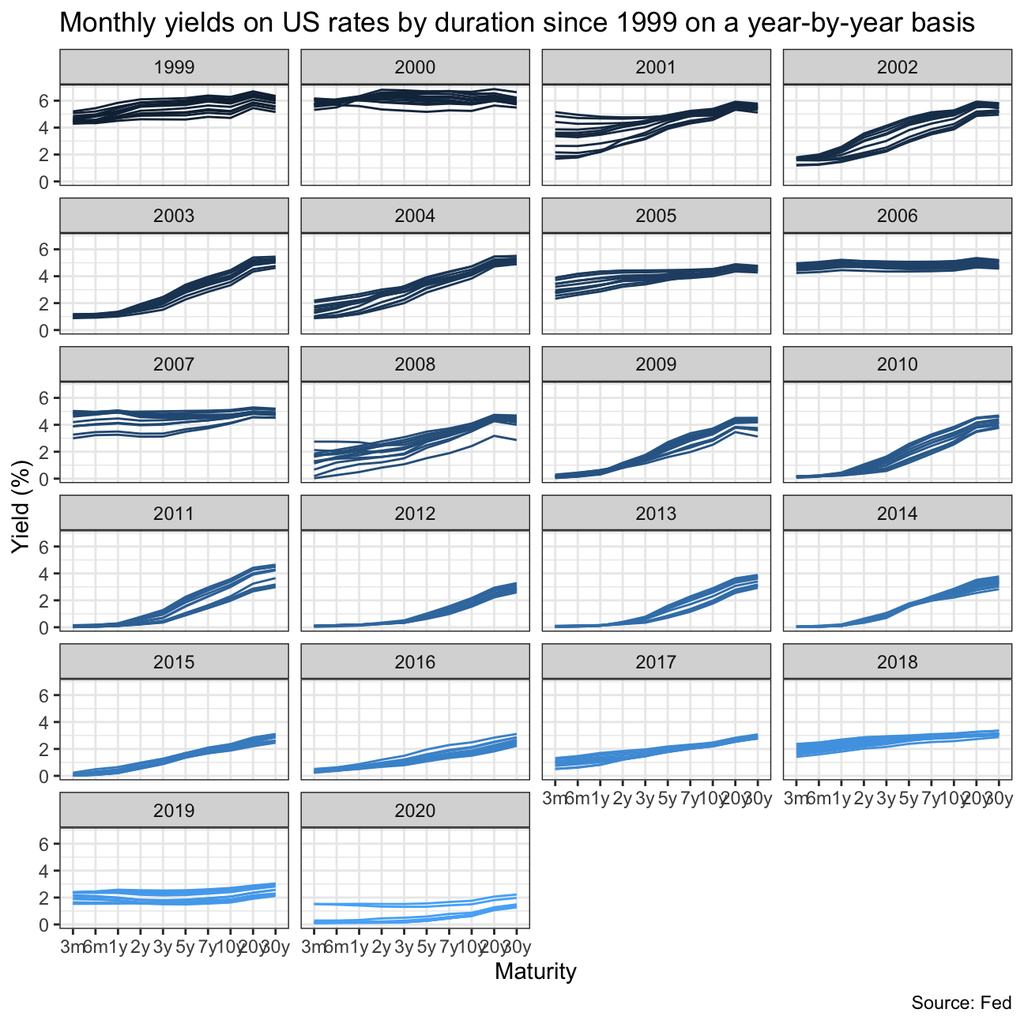

```r
yield_curve %>%
  mutate(year_of_maturity = year(date), month_of_maturity = month(date)) %>%
  filter(year_of_maturity >= 1999) %>%
  ggplot(aes(x = maturity, y = price, color = year_of_maturity, group = month_of_maturity)) +
  geom_line(alpha = 1) +
  facet_wrap(~ year_of_maturity, ncol = 4) +
  theme_bw() +
  labs(title = "Monthly yields on US rates by duration since 1999 on a year-by-year basis", caption = "Source: Fed", x = "Maturity", y = "Yield (%)") +
  theme(legend.position = "none")
```

# 3 Yield Spread

## 3.1 Yield spread between 3-month and 10-year yield T assets

To further quantify the aforementioned phenomenon where the short term rates exceed some of the long term rates, we further demonstrated the yield spread which is the yield difference between the 3-month and 10-year yields T asset. *A negative yield spread would be a indicator of the inverted yield curve.*

First, we plotted the yields for the two maturities:

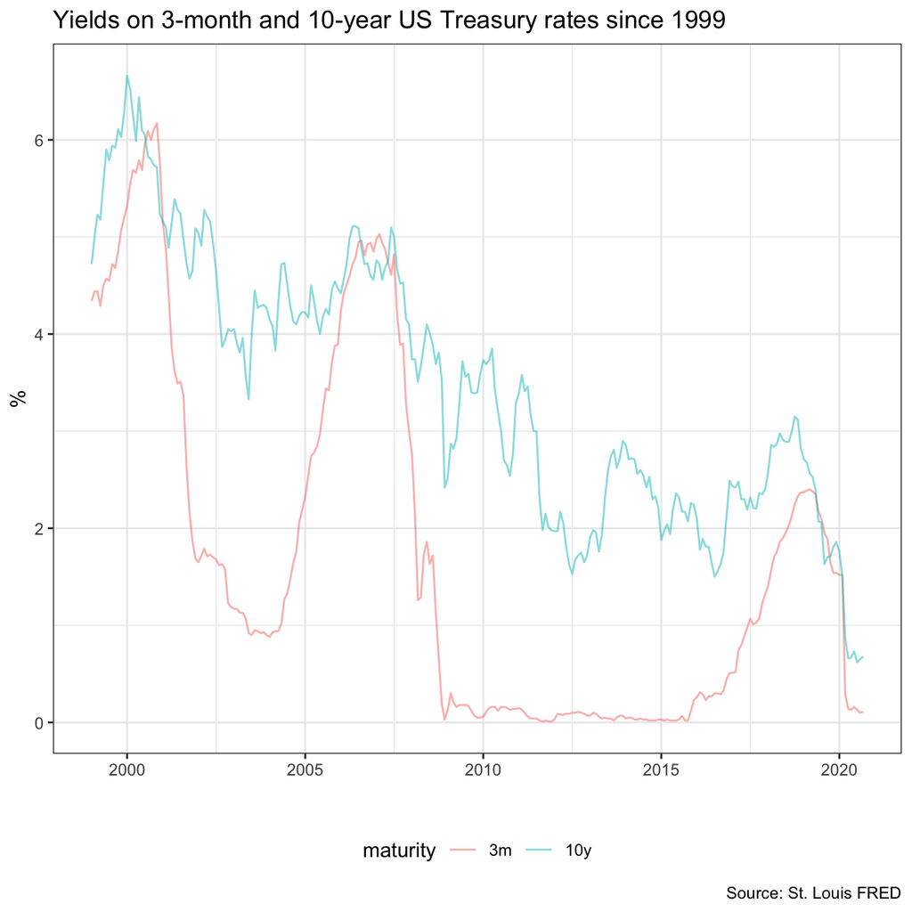

```r
yield_curve %>%
  filter(maturity %in% c("3m","10y"), year(date) >= 1999) %>%
  ggplot(aes(x = date, y = price, color = maturity, group = maturity)) +
  geom_line(alpha = 0.5) +
  theme_bw() +
  theme(legend.text = element_text(),
        legend.position = "bottom") +
  labs(title = "Yields on 3-month and 10-year US Treasury rates since 1999",
       x = "",
       y = "%",
       caption = "Source: St. Louis FRED")
```

Second, we reorganized the dataframe to create the spread between the two maturities:

```r
yield_curve_final <- yield_curve %>%
  filter((maturity == "3m" | maturity == "10y")) %>%
  select(c("date","price","var")) %>%
  pivot_wider(names_from = "var", values_from = "price") %>% # To create a 3-m and 10-y price for each dates
  mutate(difference=`10-Year Treasury Rate` - `3-Month Treasury Bill`) %>% # create the difference
  mutate(positive_difference = ifelse(difference>0, difference, 0)) %>% # for further plotting the riboon
  mutate(negative_difference = ifelse(difference<0, difference, 0)) # for further plotting the riboon

glimpse(yield_curve_final)
```

```
## Rows: 729
## Columns: 6
## $ date                    <date> 1960-01-01, 1960-02-01, 1960-03-01, 1960-04-…
## $ `3-Month Treasury Bill` <dbl> 4.35, 3.96, 3.31, 3.23, 3.29, 2.46, 2.30, 2.3…
## $ `10-Year Treasury Rate` <dbl> 4.72, 4.49, 4.25, 4.28, 4.35, 4.15, 3.90, 3.8…
## $ difference              <dbl> 0.37, 0.53, 0.94, 1.05, 1.06, 1.69, 1.60, 1.5…
## $ positive_difference     <dbl> 0.37, 0.53, 0.94, 1.05, 1.06, 1.69, 1.60, 1.5…
## $ negative_difference     <dbl> 0, 0, 0, 0, 0, 0, 0, 0, 0, 0, 0, 0, 0, 0, 0, …
```

Then, we want to compare the positive yield spread with the recession sessions to see their correlations:

```
## # A tibble: 11 x 5
##    from       to         From       To         duration_days
##    <chr>      <chr>      <date>     <date>     <drtn>
##  1 1948-11-01 1949-10-01 1948-11-01 1949-10-01 334 days
##  2 1953-07-01 1954-05-01 1953-07-01 1954-05-01 304 days
##  3 1957-08-01 1958-04-01 1957-08-01 1958-04-01 243 days
##  4 1960-04-01 1961-02-01 1960-04-01 1961-02-01 306 days
##  5 1969-12-01 1970-11-01 1969-12-01 1970-11-01 335 days
##  6 1973-11-01 1975-03-01 1973-11-01 1975-03-01 485 days
##  7 1980-01-01 1980-07-01 1980-01-01 1980-07-01 182 days
##  8 1981-07-01 1982-11-01 1981-07-01 1982-11-01 488 days
##  9 1990-07-01 1991-03-01 1990-07-01 1991-03-01 243 days
## 10 2001-03-01 2001-11-01 2001-03-01 2001-11-01 245 days
## 11 2007-12-01 2009-06-01 2007-12-01 2009-06-01 548 days
```

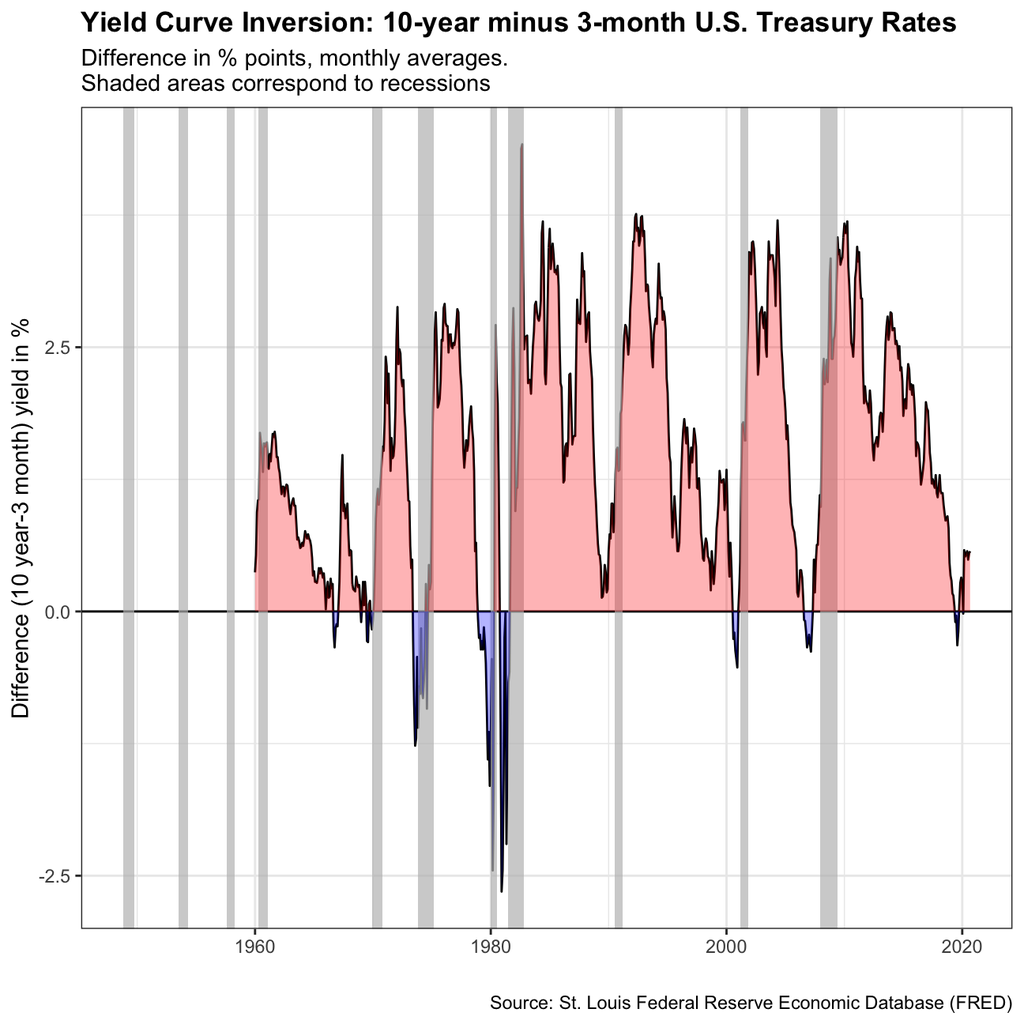

```r
ggplot(yield_curve_final, aes(x=date, y=difference)) +
  geom_line() +
  labs(y = 'Difference (10 year-3 month) yield in %', title = 'Yield Curve Inversion: 10-year minus 3-month U.S. Treasury Rates',
      caption = "Source: St. Louis Federal Reserve Economic Database (FRED)",
      subtitle = "Difference in % points, monthly averages. \nShaded areas correspond to recessions", x="") +
  theme_bw() +
  theme(plot.title = element_text(face = "bold"), legend.position = "none") +
  geom_hline(yintercept=0,color="black") +
  geom_rect(data=filter(recessions), inherit.aes=F, aes(xmin=From, xmax=To, ymin=-Inf, ymax=+Inf), fill='grey', alpha=0.7) +
  geom_ribbon(aes(ymin = 0, ymax = positive_difference), fill = "red", alpha = 0.3) +
  geom_ribbon(aes(ymin = negative_difference, ymax = 0), fill = "blue", alpha = 0.3)
```